# Risk Factor Analysis

## Outcome Variable

**Outcome Variable:** stunted

## Predictor Variables

**Intervention Variable:** impsan

**Adjustment Set:**

- arm
- sex
- W_mage
- meducyrs
- feducyrs
- hhwealth_quart
- hfoodsec
- W_mhtcm
- W_nrooms
- W_nchldlt5
- W_parity
- impfloor
- safeh20
- delta_W_mage
- delta_meducyrs
- delta_feducyrs
- delta_hhwealth_quart
- delta_hfoodsec
- delta_W_mhtcm
- delta_W_nrooms
- delta_W_nchldlt5
- delta_W_parity
- delta_impfloor
- delta_safeh20

## Stratifying Variables

The analysis was stratified on these variable(s):

- agecat
- studyid
- country

## Data Summary

| agecat | studyid | country | impsan | stunted | n_cell | n |
| --- | --- | --- | --- | --- | --- | --- |
| Birth | ki0047075b-MAL-ED | BANGLADESH | 0 | 0 | 32 | 234 |
| Birth | ki0047075b-MAL-ED | BANGLADESH | 0 | 1 | 5 | 234 |
| Birth | ki0047075b-MAL-ED | BANGLADESH | 1 | 0 | 164 | 234 |
| Birth | ki0047075b-MAL-ED | BANGLADESH | 1 | 1 | 33 | 234 |
| 6 months | ki0047075b-MAL-ED | BANGLADESH | 0 | 0 | 33 | 240 |
| 6 months | ki0047075b-MAL-ED | BANGLADESH | 0 | 1 | 5 | 240 |
| 6 months | ki0047075b-MAL-ED | BANGLADESH | 1 | 0 | 162 | 240 |
| 6 months | ki0047075b-MAL-ED | BANGLADESH | 1 | 1 | 40 | 240 |
| 24 months | ki0047075b-MAL-ED | BANGLADESH | 0 | 0 | 16 | 212 |
| 24 months | ki0047075b-MAL-ED | BANGLADESH | 0 | 1 | 15 | 212 |
| 24 months | ki0047075b-MAL-ED | BANGLADESH | 1 | 0 | 98 | 212 |
| 24 months | ki0047075b-MAL-ED | BANGLADESH | 1 | 1 | 83 | 212 |
| Birth | ki0047075b-MAL-ED | BRAZIL | 0 | 0 | 4 | 174 |
| Birth | ki0047075b-MAL-ED | BRAZIL | 0 | 1 | 0 | 174 |
| Birth | ki0047075b-MAL-ED | BRAZIL | 1 | 0 | 153 | 174 |
| Birth | ki0047075b-MAL-ED | BRAZIL | 1 | 1 | 17 | 174 |
| 6 months | ki0047075b-MAL-ED | BRAZIL | 0 | 0 | 4 | 209 |
| 6 months | ki0047075b-MAL-ED | BRAZIL | 0 | 1 | 0 | 209 |
| 6 months | ki0047075b-MAL-ED | BRAZIL | 1 | 0 | 199 | 209 |
| 6 months | ki0047075b-MAL-ED | BRAZIL | 1 | 1 | 6 | 209 |
| 24 months | ki0047075b-MAL-ED | BRAZIL | 0 | 0 | 3 | 169 |
| 24 months | ki0047075b-MAL-ED | BRAZIL | 0 | 1 | 0 | 169 |
| 24 months | ki0047075b-MAL-ED | BRAZIL | 1 | 0 | 160 | 169 |
| 24 months | ki0047075b-MAL-ED | BRAZIL | 1 | 1 | 6 | 169 |
| Birth | ki0047075b-MAL-ED | INDIA | 0 | 0 | 85 | 190 |
| Birth | ki0047075b-MAL-ED | INDIA | 0 | 1 | 13 | 190 |
| Birth | ki0047075b-MAL-ED | INDIA | 1 | 0 | 76 | 190 |
| Birth | ki0047075b-MAL-ED | INDIA | 1 | 1 | 16 | 190 |
| 6 months | ki0047075b-MAL-ED | INDIA | 0 | 0 | 98 | 233 |
| 6 months | ki0047075b-MAL-ED | INDIA | 0 | 1 | 27 | 233 |

[output cut: 158 more lines]

The following strata were considered:

- agecat: 24 months, studyid: ki0047075b-MAL-ED, country: BANGLADESH
- agecat: 24 months, studyid: ki0047075b-MAL-ED, country: BRAZIL
- agecat: 24 months, studyid: ki0047075b-MAL-ED, country: INDIA
- agecat: 24 months, studyid: ki0047075b-MAL-ED, country: NEPAL
- agecat: 24 months, studyid: ki0047075b-MAL-ED, country: PERU
- agecat: 24 months, studyid: ki0047075b-MAL-ED, country: SOUTH AFRICA
- agecat: 24 months, studyid: ki0047075b-MAL-ED, country: TANZANIA, UNITED REPUBLIC OF
- agecat: 24 months, studyid: ki1017093-NIH-Birth, country: BANGLADESH
- agecat: 24 months, studyid: ki1017093b-PROVIDE, country: BANGLADESH
- agecat: 24 months, studyid: ki1017093c-NIH-Crypto, country: BANGLADESH
- agecat: 24 months, studyid: ki1114097-CONTENT, country: PERU
- agecat: 24 months, studyid: ki1135781-COHORTS, country: GUATEMALA
- agecat: 24 months, studyid: ki1135781-COHORTS, country: INDIA
- agecat: 24 months, studyid: ki1135781-COHORTS, country: PHILIPPINES
- agecat: 24 months, studyid: ki1148112-LCNI-5, country: MALAWI
- agecat: 24 months, studyid: kiGH5241-JiVitA-3, country: BANGLADESH
- agecat: 24 months, studyid: kiGH5241-JiVitA-4, country: BANGLADESH
- agecat: 6 months, studyid: ki0047075b-MAL-ED, country: BANGLADESH
- agecat: 6 months, studyid: ki0047075b-MAL-ED, country: BRAZIL
- agecat: 6 months, studyid: ki0047075b-MAL-ED, country: INDIA
- agecat: 6 months, studyid: ki0047075b-MAL-ED, country: NEPAL
- agecat: 6 months, studyid: ki0047075b-MAL-ED, country: PERU
- agecat: 6 months, studyid: ki0047075b-MAL-ED, country: SOUTH AFRICA
- agecat: 6 months, studyid: ki0047075b-MAL-ED, country: TANZANIA, UNITED REPUBLIC OF
- agecat: 6 months, studyid: ki1017093-NIH-Birth, country: BANGLADESH
- agecat: 6 months, studyid: ki1017093b-PROVIDE, country: BANGLADESH
- agecat: 6 months, studyid: ki1017093c-NIH-Crypto, country: BANGLADESH
- agecat: 6 months, studyid: ki1114097-CONTENT, country: PERU
- agecat: 6 months, studyid: ki1135781-COHORTS, country: GUATEMALA
- agecat: 6 months, studyid: ki1135781-COHORTS, country: INDIA
- agecat: 6 months, studyid: ki1135781-COHORTS, country: PHILIPPINES
- agecat: 6 months, studyid: ki1148112-LCNI-5, country: MALAWI
- agecat: 6 months, studyid: kiGH5241-JiVitA-3, country: BANGLADESH
- agecat: 6 months, studyid: kiGH5241-JiVitA-4, country: BANGLADESH
- agecat: Birth, studyid: ki0047075b-MAL-ED, country: BANGLADESH
- agecat: Birth, studyid: ki0047075b-MAL-ED, country: BRAZIL
- agecat: Birth, studyid: ki0047075b-MAL-ED, country: INDIA
- agecat: Birth, studyid: ki0047075b-MAL-ED, country: NEPAL
- agecat: Birth, studyid: ki0047075b-MAL-ED, country: PERU
- agecat: Birth, studyid: ki0047075b-MAL-ED, country: SOUTH AFRICA
- agecat: Birth, studyid: ki0047075b-MAL-ED, country: TANZANIA, UNITED REPUBLIC OF
- agecat: Birth, studyid: ki1017093-NIH-Birth, country: BANGLADESH
- agecat: Birth, studyid: ki1017093c-NIH-Crypto, country: BANGLADESH
- agecat: Birth, studyid: ki1114097-CONTENT, country: PERU
- agecat: Birth, studyid: ki1135781-COHORTS, country: GUATEMALA
- agecat: Birth, studyid: ki1135781-COHORTS, country: INDIA
- agecat: Birth, studyid: ki1135781-COHORTS, country: PHILIPPINES
- agecat: Birth, studyid: kiGH5241-JiVitA-3, country: BANGLADESH
- agecat: Birth, studyid: kiGH5241-JiVitA-4, country: BANGLADESH

### Dropped Strata

Some strata were dropped due to rare outcomes:

- agecat: Birth, studyid: ki0047075b-MAL-ED, country: BRAZIL
- agecat: 6 months, studyid: ki0047075b-MAL-ED, country: BRAZIL
- agecat: 24 months, studyid: ki0047075b-MAL-ED, country: BRAZIL
- agecat: 6 months, studyid: ki0047075b-MAL-ED, country: NEPAL
- agecat: 24 months, studyid: ki0047075b-MAL-ED, country: NEPAL
- agecat: Birth, studyid: ki0047075b-MAL-ED, country: NEPAL
- agecat: Birth, studyid: ki0047075b-MAL-ED, country: SOUTH AFRICA
- agecat: 6 months, studyid: ki0047075b-MAL-ED, country: SOUTH AFRICA
- agecat: 24 months, studyid: ki0047075b-MAL-ED, country: SOUTH AFRICA
- agecat: Birth, studyid: ki1017093-NIH-Birth, country: BANGLADESH
- agecat: Birth, studyid: ki1017093c-NIH-Crypto, country: BANGLADESH
- agecat: 6 months, studyid: ki1114097-CONTENT, country: PERU
- agecat: 24 months, studyid: ki1114097-CONTENT, country: PERU
- agecat: Birth, studyid: ki1114097-CONTENT, country: PERU
- agecat: Birth, studyid: ki1135781-COHORTS, country: GUATEMALA
- agecat: Birth, studyid: ki1135781-COHORTS, country: PHILIPPINES
- agecat: 6 months, studyid: ki1148112-LCNI-5, country: MALAWI
- agecat: 24 months, studyid: ki1148112-LCNI-5, country: MALAWI

## Methods Detail

We’re interested in the causal parameters $E[Y_a]$ for all values of $a \in \mathcal{A}$. These parameters represent the mean outcome if, possibly contrary to fact, we intervened to set all units to have $A=a$. Under the randomization and positivity assumptions, these are identified by the statistical parameters $\psi_a=E_W[E_{Y|A,W}(Y|A=a,W)]$. In addition, we’re interested in the mean of $Y$, $E[Y]$ under no intervention (the observed mean). We will estimate these parameters by using SuperLearner to fit the relevant likelihood factors – $E_{Y|A,W}(Y|A=a,W)$ and $p(A=a|W)$, and then updating our likelihood fit using a joint TMLE.

For unadjusted analyses ($W=\{\}$), initial likelihoods were estimated using Lrnr_glm to estimate the simple $E(Y|A)$ and Lrnr_mean to estimate $p(A)$. For adjusted analyses, a small library containing Lrnr_glmnet, Lrnr_xgboost, and Lrnr_mean was used.

Having estimated these parameters, we will then use the delta method to estimate relative risks and attributable risks relative to a prespecified baseline level of $A$.

```
##       stunted
## impsan   0   1
##      0  58 149
##      1   0   0
##       stunted
## impsan   0   1
##      0 181  57
##      1   0   0
##       stunted
## impsan  0  1
##      0 97 16
##      1  0  0
```

# Results Detail

## Results Plots

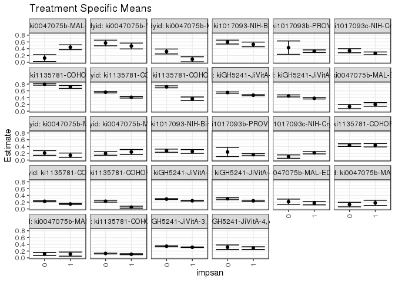

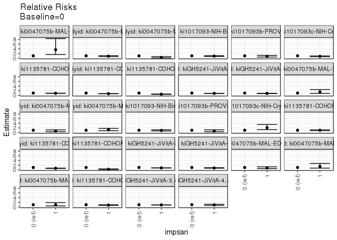

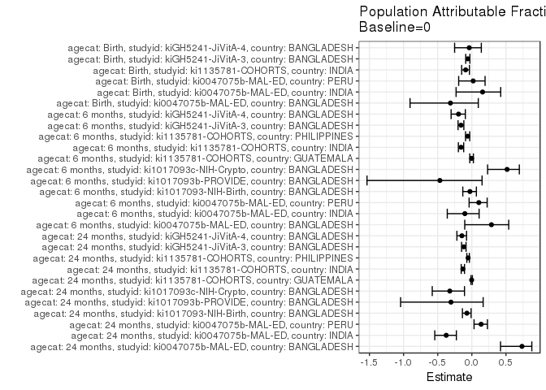

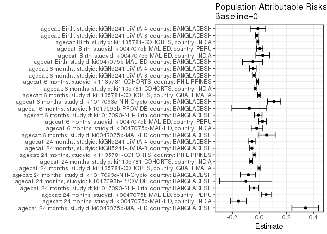

## Results Table

### Parameter: TSM

| agecat | studyid | country | intervention_level | baseline_level | estimate | ci_lower | ci_upper |
| --- | --- | --- | --- | --- | --- | --- | --- |
| Birth | ki0047075b-MAL-ED | BANGLADESH | 0 | NA | 0.2132864 | 0.1364725 | 0.2901003 |
| Birth | ki0047075b-MAL-ED | BANGLADESH | 1 | NA | 0.1726281 | 0.1210359 | 0.2242202 |
| Birth | ki0047075b-MAL-ED | INDIA | 0 | NA | 0.1286145 | 0.0620280 | 0.1952010 |
| Birth | ki0047075b-MAL-ED | INDIA | 1 | NA | 0.1793592 | 0.1023291 | 0.2563892 |
| Birth | ki0047075b-MAL-ED | PERU | 0 | NA | 0.1137375 | 0.0695416 | 0.1579334 |
| Birth | ki0047075b-MAL-ED | PERU | 1 | NA | 0.1104636 | 0.0499980 | 0.1709291 |
| Birth | ki1135781-COHORTS | INDIA | 0 | NA | 0.1290106 | 0.1174176 | 0.1406037 |
| Birth | ki1135781-COHORTS | INDIA | 1 | NA | 0.1061697 | 0.0922506 | 0.1200888 |
| Birth | kiGH5241-JiVitA-3 | BANGLADESH | 0 | NA | 0.3422547 | 0.3301665 | 0.3543429 |
| Birth | kiGH5241-JiVitA-3 | BANGLADESH | 1 | NA | 0.3116865 | 0.3025791 | 0.3207940 |
| Birth | kiGH5241-JiVitA-4 | BANGLADESH | 0 | NA | 0.3120085 | 0.2441980 | 0.3798189 |
| Birth | kiGH5241-JiVitA-4 | BANGLADESH | 1 | NA | 0.2864692 | 0.2457709 | 0.3271674 |
| 6 months | ki0047075b-MAL-ED | BANGLADESH | 0 | NA | 0.1335863 | 0.0721343 | 0.1950382 |
| 6 months | ki0047075b-MAL-ED | BANGLADESH | 1 | NA | 0.1974402 | 0.1440591 | 0.2508214 |
| 6 months | ki0047075b-MAL-ED | INDIA | 0 | NA | 0.2081448 | 0.1387540 | 0.2775356 |
| 6 months | ki0047075b-MAL-ED | INDIA | 1 | NA | 0.1411592 | 0.0757831 | 0.2065354 |
| 6 months | ki0047075b-MAL-ED | PERU | 0 | NA | 0.1946333 | 0.1417671 | 0.2474994 |
| 6 months | ki0047075b-MAL-ED | PERU | 1 | NA | 0.2371544 | 0.1643300 | 0.3099789 |
| 6 months | ki1017093-NIH-Birth | BANGLADESH | 0 | NA | 0.2756895 | 0.2293805 | 0.3219985 |
| 6 months | ki1017093-NIH-Birth | BANGLADESH | 1 | NA | 0.2534941 | 0.1974804 | 0.3095078 |
| 6 months | ki1017093b-PROVIDE | BANGLADESH | 0 | NA | 0.2375455 | 0.1031658 | 0.3719252 |
| 6 months | ki1017093b-PROVIDE | BANGLADESH | 1 | NA | 0.1584328 | 0.1281300 | 0.1887356 |
| 6 months | ki1017093c-NIH-Crypto | BANGLADESH | 0 | NA | 0.1016709 | 0.0517571 | 0.1515846 |
| 6 months | ki1017093c-NIH-Crypto | BANGLADESH | 1 | NA | 0.2134115 | 0.1813571 | 0.2454659 |
| 6 months | ki1135781-COHORTS | GUATEMALA | 0 | NA | 0.4405715 | 0.4012590 | 0.4798840 |
| 6 months | ki1135781-COHORTS | GUATEMALA | 1 | NA | 0.4368269 | 0.3868714 | 0.4867824 |
| 6 months | ki1135781-COHORTS | INDIA | 0 | NA | 0.2265685 | 0.2125055 | 0.2406314 |
| 6 months | ki1135781-COHORTS | INDIA | 1 | NA | 0.1462170 | 0.1309576 | 0.1614763 |
| 6 months | ki1135781-COHORTS | PHILIPPINES | 0 | NA | 0.2283174 | 0.2017447 | 0.2548902 |
| 6 months | ki1135781-COHORTS | PHILIPPINES | 1 | NA | 0.0525272 | 0.0241514 | 0.0809030 |
| 6 months | kiGH5241-JiVitA-3 | BANGLADESH | 0 | NA | 0.2912932 | 0.2788070 | 0.3037794 |
| 6 months | kiGH5241-JiVitA-3 | BANGLADESH | 1 | NA | 0.2416363 | 0.2324603 | 0.2508123 |
| 6 months | kiGH5241-JiVitA-4 | BANGLADESH | 0 | NA | 0.3014032 | 0.2725235 | 0.3302828 |
| 6 months | kiGH5241-JiVitA-4 | BANGLADESH | 1 | NA | 0.2402246 | 0.2242857 | 0.2561635 |
| 24 months | ki0047075b-MAL-ED | BANGLADESH | 0 | NA | 0.1225203 | 0.0211477 | 0.2238929 |
| 24 months | ki0047075b-MAL-ED | BANGLADESH | 1 | NA | 0.4432780 | 0.3725515 | 0.5140045 |
| 24 months | ki0047075b-MAL-ED | INDIA | 0 | NA | 0.5685893 | 0.4852350 | 0.6519436 |
| 24 months | ki0047075b-MAL-ED | INDIA | 1 | NA | 0.4791247 | 0.3927251 | 0.5655243 |
| 24 months | ki0047075b-MAL-ED | PERU | 0 | NA | 0.3174445 | 0.2440696 | 0.3908195 |
| 24 months | ki0047075b-MAL-ED | PERU | 1 | NA | 0.0874577 | 0.0129291 | 0.1619863 |
| 24 months | ki1017093-NIH-Birth | BANGLADESH | 0 | NA | 0.5949824 | 0.5377937 | 0.6521711 |
| 24 months | ki1017093-NIH-Birth | BANGLADESH | 1 | NA | 0.5264390 | 0.4575353 | 0.5953428 |
| 24 months | ki1017093b-PROVIDE | BANGLADESH | 0 | NA | 0.4306752 | 0.2329152 | 0.6284353 |
| 24 months | ki1017093b-PROVIDE | BANGLADESH | 1 | NA | 0.3253393 | 0.2863040 | 0.3643745 |
| 24 months | ki1017093c-NIH-Crypto | BANGLADESH | 0 | NA | 0.3392718 | 0.2792117 | 0.3993319 |
| 24 months | ki1017093c-NIH-Crypto | BANGLADESH | 1 | NA | 0.2628524 | 0.2225756 | 0.3031291 |
| 24 months | ki1135781-COHORTS | GUATEMALA | 0 | NA | 0.7933520 | 0.7662378 | 0.8204662 |
| 24 months | ki1135781-COHORTS | GUATEMALA | 1 | NA | 0.7130770 | 0.6701725 | 0.7559815 |
| 24 months | ki1135781-COHORTS | INDIA | 0 | NA | 0.5578392 | 0.5387135 | 0.5769650 |
| 24 months | ki1135781-COHORTS | INDIA | 1 | NA | 0.4092186 | 0.3867237 | 0.4317136 |
| 24 months | ki1135781-COHORTS | PHILIPPINES | 0 | NA | 0.7178790 | 0.6885137 | 0.7472444 |
| 24 months | ki1135781-COHORTS | PHILIPPINES | 1 | NA | 0.3650124 | 0.3118605 | 0.4181643 |
| 24 months | kiGH5241-JiVitA-3 | BANGLADESH | 0 | NA | 0.5483034 | 0.5292026 | 0.5674042 |
| 24 months | kiGH5241-JiVitA-3 | BANGLADESH | 1 | NA | 0.4703192 | 0.4556454 | 0.4849929 |
| 24 months | kiGH5241-JiVitA-4 | BANGLADESH | 0 | NA | 0.4494680 | 0.4197789 | 0.4791570 |
| 24 months | kiGH5241-JiVitA-4 | BANGLADESH | 1 | NA | 0.3788353 | 0.3592710 | 0.3983996 |

### Parameter: E(Y)

| agecat | studyid | country | intervention_level | baseline_level | estimate | ci_lower | ci_upper |
| --- | --- | --- | --- | --- | --- | --- | --- |
| Birth | ki0047075b-MAL-ED | BANGLADESH | NA | NA | 0.1623932 | 0.1150373 | 0.2097491 |
| Birth | ki0047075b-MAL-ED | INDIA | NA | NA | 0.1526316 | 0.1013601 | 0.2039030 |
| Birth | ki0047075b-MAL-ED | PERU | NA | NA | 0.1160000 | 0.0762256 | 0.1557744 |
| Birth | ki1135781-COHORTS | INDIA | NA | NA | 0.1182998 | 0.1091394 | 0.1274602 |
| Birth | kiGH5241-JiVitA-3 | BANGLADESH | NA | NA | 0.3233463 | 0.3156839 | 0.3310086 |
| Birth | kiGH5241-JiVitA-4 | BANGLADESH | NA | NA | 0.3004866 | 0.2649179 | 0.3360553 |
| 6 months | ki0047075b-MAL-ED | BANGLADESH | NA | NA | 0.1875000 | 0.1380164 | 0.2369836 |
| 6 months | ki0047075b-MAL-ED | INDIA | NA | NA | 0.1888412 | 0.1384789 | 0.2392035 |
| 6 months | ki0047075b-MAL-ED | PERU | NA | NA | 0.2167300 | 0.1668401 | 0.2666199 |
| 6 months | ki1017093-NIH-Birth | BANGLADESH | NA | NA | 0.2681564 | 0.2306532 | 0.3056597 |
| 6 months | ki1017093b-PROVIDE | BANGLADESH | NA | NA | 0.1617900 | 0.1318200 | 0.1917600 |
| 6 months | ki1017093c-NIH-Crypto | BANGLADESH | NA | NA | 0.2102273 | 0.1801065 | 0.2403480 |
| 6 months | ki1135781-COHORTS | GUATEMALA | NA | NA | 0.4392097 | 0.4012606 | 0.4771588 |
| 6 months | ki1135781-COHORTS | INDIA | NA | NA | 0.1957353 | 0.1847045 | 0.2067660 |
| 6 months | ki1135781-COHORTS | PHILIPPINES | NA | NA | 0.2151431 | 0.1906585 | 0.2396277 |
| 6 months | kiGH5241-JiVitA-3 | BANGLADESH | NA | NA | 0.2514286 | 0.2432891 | 0.2595681 |
| 6 months | kiGH5241-JiVitA-4 | BANGLADESH | NA | NA | 0.2522280 | 0.2381653 | 0.2662906 |
| 24 months | ki0047075b-MAL-ED | BANGLADESH | NA | NA | 0.4622642 | 0.3949918 | 0.5295365 |
| 24 months | ki0047075b-MAL-ED | INDIA | NA | NA | 0.4133333 | 0.3488467 | 0.4778200 |
| 24 months | ki0047075b-MAL-ED | PERU | NA | NA | 0.3673469 | 0.2996839 | 0.4350100 |
| 24 months | ki1017093-NIH-Birth | BANGLADESH | NA | NA | 0.5547786 | 0.5076945 | 0.6018626 |
| 24 months | ki1017093b-PROVIDE | BANGLADESH | NA | NA | 0.3298611 | 0.2914318 | 0.3682904 |
| 24 months | ki1017093c-NIH-Crypto | BANGLADESH | NA | NA | 0.2564612 | 0.2182616 | 0.2946608 |
| 24 months | ki1135781-COHORTS | GUATEMALA | NA | NA | 0.7912946 | 0.7646707 | 0.8179186 |
| 24 months | ki1135781-COHORTS | INDIA | NA | NA | 0.4930741 | 0.4770789 | 0.5090692 |
| 24 months | ki1135781-COHORTS | PHILIPPINES | NA | NA | 0.6808081 | 0.6517553 | 0.7098609 |
| 24 months | kiGH5241-JiVitA-3 | BANGLADESH | NA | NA | 0.4908374 | 0.4777103 | 0.5039644 |
| 24 months | kiGH5241-JiVitA-4 | BANGLADESH | NA | NA | 0.3922477 | 0.3752571 | 0.4092384 |

### Parameter: RR

| agecat | studyid | country | intervention_level | baseline_level | estimate | ci_lower | ci_upper |
| --- | --- | --- | --- | --- | --- | --- | --- |
| Birth | ki0047075b-MAL-ED | BANGLADESH | 0 | 0 | 1.0000000 | 1.0000000 | 1.0000000 |
| Birth | ki0047075b-MAL-ED | BANGLADESH | 1 | 0 | 0.8093720 | 0.5068368 | 1.2924931 |
| Birth | ki0047075b-MAL-ED | INDIA | 0 | 0 | 1.0000000 | 1.0000000 | 1.0000000 |
| Birth | ki0047075b-MAL-ED | INDIA | 1 | 0 | 1.3945485 | 0.7165883 | 2.7139228 |
| Birth | ki0047075b-MAL-ED | PERU | 0 | 0 | 1.0000000 | 1.0000000 | 1.0000000 |
| Birth | ki0047075b-MAL-ED | PERU | 1 | 0 | 0.9712151 | 0.5028288 | 1.8759045 |
| Birth | ki1135781-COHORTS | INDIA | 0 | 0 | 1.0000000 | 1.0000000 | 1.0000000 |
| Birth | ki1135781-COHORTS | INDIA | 1 | 0 | 0.8229535 | 0.7022587 | 0.9643917 |
| Birth | kiGH5241-JiVitA-3 | BANGLADESH | 0 | 0 | 1.0000000 | 1.0000000 | 1.0000000 |
| Birth | kiGH5241-JiVitA-3 | BANGLADESH | 1 | 0 | 0.9106859 | 0.8718443 | 0.9512580 |
| Birth | kiGH5241-JiVitA-4 | BANGLADESH | 0 | 0 | 1.0000000 | 1.0000000 | 1.0000000 |
| Birth | kiGH5241-JiVitA-4 | BANGLADESH | 1 | 0 | 0.9181455 | 0.7078479 | 1.1909214 |
| 6 months | ki0047075b-MAL-ED | BANGLADESH | 0 | 0 | 1.0000000 | 1.0000000 | 1.0000000 |
| 6 months | ki0047075b-MAL-ED | BANGLADESH | 1 | 0 | 1.4779979 | 0.8799010 | 2.4826403 |
| 6 months | ki0047075b-MAL-ED | INDIA | 0 | 0 | 1.0000000 | 1.0000000 | 1.0000000 |
| 6 months | ki0047075b-MAL-ED | INDIA | 1 | 0 | 0.6781781 | 0.3859756 | 1.1915922 |
| 6 months | ki0047075b-MAL-ED | PERU | 0 | 0 | 1.0000000 | 1.0000000 | 1.0000000 |
| 6 months | ki0047075b-MAL-ED | PERU | 1 | 0 | 1.2184681 | 0.8133127 | 1.8254535 |
| 6 months | ki1017093-NIH-Birth | BANGLADESH | 0 | 0 | 1.0000000 | 1.0000000 | 1.0000000 |
| 6 months | ki1017093-NIH-Birth | BANGLADESH | 1 | 0 | 0.9194914 | 0.7046816 | 1.1997822 |
| 6 months | ki1017093b-PROVIDE | BANGLADESH | 0 | 0 | 1.0000000 | 1.0000000 | 1.0000000 |
| 6 months | ki1017093b-PROVIDE | BANGLADESH | 1 | 0 | 0.6669575 | 0.3708649 | 1.1994456 |
| 6 months | ki1017093c-NIH-Crypto | BANGLADESH | 0 | 0 | 1.0000000 | 1.0000000 | 1.0000000 |
| 6 months | ki1017093c-NIH-Crypto | BANGLADESH | 1 | 0 | 2.0990423 | 1.2580643 | 3.5021887 |
| 6 months | ki1135781-COHORTS | GUATEMALA | 0 | 0 | 1.0000000 | 1.0000000 | 1.0000000 |
| 6 months | ki1135781-COHORTS | GUATEMALA | 1 | 0 | 0.9915005 | 0.8618141 | 1.1407023 |
| 6 months | ki1135781-COHORTS | INDIA | 0 | 0 | 1.0000000 | 1.0000000 | 1.0000000 |
| 6 months | ki1135781-COHORTS | INDIA | 1 | 0 | 0.6453544 | 0.5722441 | 0.7278054 |
| 6 months | ki1135781-COHORTS | PHILIPPINES | 0 | 0 | 1.0000000 | 1.0000000 | 1.0000000 |
| 6 months | ki1135781-COHORTS | PHILIPPINES | 1 | 0 | 0.2300622 | 0.1326696 | 0.3989506 |
| 6 months | kiGH5241-JiVitA-3 | BANGLADESH | 0 | 0 | 1.0000000 | 1.0000000 | 1.0000000 |
| 6 months | kiGH5241-JiVitA-3 | BANGLADESH | 1 | 0 | 0.8295296 | 0.7869221 | 0.8744440 |
| 6 months | kiGH5241-JiVitA-4 | BANGLADESH | 0 | 0 | 1.0000000 | 1.0000000 | 1.0000000 |
| 6 months | kiGH5241-JiVitA-4 | BANGLADESH | 1 | 0 | 0.7970207 | 0.7075019 | 0.8978662 |
| 24 months | ki0047075b-MAL-ED | BANGLADESH | 0 | 0 | 1.0000000 | 1.0000000 | 1.0000000 |
| 24 months | ki0047075b-MAL-ED | BANGLADESH | 1 | 0 | 3.6179973 | 1.5663107 | 8.3571572 |
| 24 months | ki0047075b-MAL-ED | INDIA | 0 | 0 | 1.0000000 | 1.0000000 | 1.0000000 |
| 24 months | ki0047075b-MAL-ED | INDIA | 1 | 0 | 0.8426551 | 0.6688884 | 1.0615635 |
| 24 months | ki0047075b-MAL-ED | PERU | 0 | 0 | 1.0000000 | 1.0000000 | 1.0000000 |
| 24 months | ki0047075b-MAL-ED | PERU | 1 | 0 | 0.2755055 | 0.1133408 | 0.6696909 |
| 24 months | ki1017093-NIH-Birth | BANGLADESH | 0 | 0 | 1.0000000 | 1.0000000 | 1.0000000 |
| 24 months | ki1017093-NIH-Birth | BANGLADESH | 1 | 0 | 0.8847976 | 0.7568749 | 1.0343410 |
| 24 months | ki1017093b-PROVIDE | BANGLADESH | 0 | 0 | 1.0000000 | 1.0000000 | 1.0000000 |
| 24 months | ki1017093b-PROVIDE | BANGLADESH | 1 | 0 | 0.7554167 | 0.4704254 | 1.2130605 |
| 24 months | ki1017093c-NIH-Crypto | BANGLADESH | 0 | 0 | 1.0000000 | 1.0000000 | 1.0000000 |
| 24 months | ki1017093c-NIH-Crypto | BANGLADESH | 1 | 0 | 0.7747545 | 0.6195012 | 0.9689159 |
| 24 months | ki1135781-COHORTS | GUATEMALA | 0 | 0 | 1.0000000 | 1.0000000 | 1.0000000 |
| 24 months | ki1135781-COHORTS | GUATEMALA | 1 | 0 | 0.8988154 | 0.8409669 | 0.9606432 |
| 24 months | ki1135781-COHORTS | INDIA | 0 | 0 | 1.0000000 | 1.0000000 | 1.0000000 |
| 24 months | ki1135781-COHORTS | INDIA | 1 | 0 | 0.7335781 | 0.6890476 | 0.7809864 |
| 24 months | ki1135781-COHORTS | PHILIPPINES | 0 | 0 | 1.0000000 | 1.0000000 | 1.0000000 |
| 24 months | ki1135781-COHORTS | PHILIPPINES | 1 | 0 | 0.5084595 | 0.4379541 | 0.5903155 |
| 24 months | kiGH5241-JiVitA-3 | BANGLADESH | 0 | 0 | 1.0000000 | 1.0000000 | 1.0000000 |
| 24 months | kiGH5241-JiVitA-3 | BANGLADESH | 1 | 0 | 0.8577718 | 0.8213511 | 0.8958075 |
| 24 months | kiGH5241-JiVitA-4 | BANGLADESH | 0 | 0 | 1.0000000 | 1.0000000 | 1.0000000 |
| 24 months | kiGH5241-JiVitA-4 | BANGLADESH | 1 | 0 | 0.8428527 | 0.7761179 | 0.9153256 |

### Parameter: PAR

| agecat | studyid | country | intervention_level | baseline_level | estimate | ci_lower | ci_upper |
| --- | --- | --- | --- | --- | --- | --- | --- |
| Birth | ki0047075b-MAL-ED | BANGLADESH | 0 | NA | -0.0508933 | -0.1250502 | 0.0232637 |
| Birth | ki0047075b-MAL-ED | INDIA | 0 | NA | 0.0240171 | -0.0249877 | 0.0730219 |
| Birth | ki0047075b-MAL-ED | PERU | 0 | NA | 0.0022625 | -0.0200652 | 0.0245902 |
| Birth | ki1135781-COHORTS | INDIA | 0 | NA | -0.0107108 | -0.0174372 | -0.0039843 |
| Birth | kiGH5241-JiVitA-3 | BANGLADESH | 0 | NA | -0.0189084 | -0.0286826 | -0.0091343 |
| Birth | kiGH5241-JiVitA-4 | BANGLADESH | 0 | NA | -0.0115218 | -0.0699172 | 0.0468735 |
| 6 months | ki0047075b-MAL-ED | BANGLADESH | 0 | NA | 0.0539137 | -0.0091960 | 0.1170235 |
| 6 months | ki0047075b-MAL-ED | INDIA | 0 | NA | -0.0193036 | -0.0631307 | 0.0245235 |
| 6 months | ki0047075b-MAL-ED | PERU | 0 | NA | 0.0220968 | -0.0069495 | 0.0511431 |
| 6 months | ki1017093-NIH-Birth | BANGLADESH | 0 | NA | -0.0075331 | -0.0341860 | 0.0191198 |
| 6 months | ki1017093b-PROVIDE | BANGLADESH | 0 | NA | -0.0757555 | -0.2054412 | 0.0539303 |
| 6 months | ki1017093c-NIH-Crypto | BANGLADESH | 0 | NA | 0.1085564 | 0.0594808 | 0.1576320 |
| 6 months | ki1135781-COHORTS | GUATEMALA | 0 | NA | -0.0013618 | -0.0128852 | 0.0101617 |
| 6 months | ki1135781-COHORTS | INDIA | 0 | NA | -0.0308332 | -0.0384347 | -0.0232317 |
| 6 months | ki1135781-COHORTS | PHILIPPINES | 0 | NA | -0.0131743 | -0.0198890 | -0.0064597 |
| 6 months | kiGH5241-JiVitA-3 | BANGLADESH | 0 | NA | -0.0398646 | -0.0502826 | -0.0294467 |
| 6 months | kiGH5241-JiVitA-4 | BANGLADESH | 0 | NA | -0.0491752 | -0.0751269 | -0.0232235 |
| 24 months | ki0047075b-MAL-ED | BANGLADESH | 0 | NA | 0.3397439 | 0.2422179 | 0.4372699 |
| 24 months | ki0047075b-MAL-ED | INDIA | 0 | NA | -0.1552560 | -0.2138317 | -0.0966803 |
| 24 months | ki0047075b-MAL-ED | PERU | 0 | NA | 0.0499024 | 0.0143452 | 0.0854596 |
| 24 months | ki1017093-NIH-Birth | BANGLADESH | 0 | NA | -0.0402039 | -0.0751434 | -0.0052643 |
| 24 months | ki1017093b-PROVIDE | BANGLADESH | 0 | NA | -0.1008141 | -0.2936944 | 0.0920662 |
| 24 months | ki1017093c-NIH-Crypto | BANGLADESH | 0 | NA | -0.0828106 | -0.1389783 | -0.0266428 |
| 24 months | ki1135781-COHORTS | GUATEMALA | 0 | NA | -0.0020573 | -0.0101319 | 0.0060173 |
| 24 months | ki1135781-COHORTS | INDIA | 0 | NA | -0.0647652 | -0.0763366 | -0.0531938 |
| 24 months | ki1135781-COHORTS | PHILIPPINES | 0 | NA | -0.0370709 | -0.0493499 | -0.0247920 |
| 24 months | kiGH5241-JiVitA-3 | BANGLADESH | 0 | NA | -0.0574660 | -0.0732150 | -0.0417170 |
| 24 months | kiGH5241-JiVitA-4 | BANGLADESH | 0 | NA | -0.0572202 | -0.0844286 | -0.0300119 |

### Parameter: PAF

| agecat | studyid | country | intervention_level | baseline_level | estimate | ci_lower | ci_upper |
| --- | --- | --- | --- | --- | --- | --- | --- |
| Birth | ki0047075b-MAL-ED | BANGLADESH | 0 | NA | -0.3133953 | -0.9053320 | 0.0946422 |
| Birth | ki0047075b-MAL-ED | INDIA | 0 | NA | 0.1573533 | -0.2306277 | 0.4230152 |
| Birth | ki0047075b-MAL-ED | PERU | 0 | NA | 0.0195044 | -0.1927257 | 0.1939709 |
| Birth | ki1135781-COHORTS | INDIA | 0 | NA | -0.0905392 | -0.1490478 | -0.0350098 |
| Birth | kiGH5241-JiVitA-3 | BANGLADESH | 0 | NA | -0.0584773 | -0.0892510 | -0.0285731 |
| Birth | kiGH5241-JiVitA-4 | BANGLADESH | 0 | NA | -0.0383439 | -0.2522206 | 0.1390030 |
| 6 months | ki0047075b-MAL-ED | BANGLADESH | 0 | NA | 0.2875398 | -0.1039134 | 0.5401818 |
| 6 months | ki0047075b-MAL-ED | INDIA | 0 | NA | -0.1022213 | -0.3597960 | 0.1065632 |
| 6 months | ki0047075b-MAL-ED | PERU | 0 | NA | 0.1019553 | -0.0398917 | 0.2244536 |
| 6 months | ki1017093-NIH-Birth | BANGLADESH | 0 | NA | -0.0280921 | -0.1324741 | 0.0666688 |
| 6 months | ki1017093b-PROVIDE | BANGLADESH | 0 | NA | -0.4682334 | -1.5360369 | 0.1499693 |
| 6 months | ki1017093c-NIH-Crypto | BANGLADESH | 0 | NA | 0.5163763 | 0.2308998 | 0.6958890 |
| 6 months | ki1135781-COHORTS | GUATEMALA | 0 | NA | -0.0031005 | -0.0296934 | 0.0228056 |
| 6 months | ki1135781-COHORTS | INDIA | 0 | NA | -0.1575250 | -0.1970664 | -0.1192896 |
| 6 months | ki1135781-COHORTS | PHILIPPINES | 0 | NA | -0.0612352 | -0.0923626 | -0.0309947 |
| 6 months | kiGH5241-JiVitA-3 | BANGLADESH | 0 | NA | -0.1585524 | -0.2016497 | -0.1170008 |
| 6 months | kiGH5241-JiVitA-4 | BANGLADESH | 0 | NA | -0.1949633 | -0.3036366 | -0.0953492 |
| 24 months | ki0047075b-MAL-ED | BANGLADESH | 0 | NA | 0.7349561 | 0.4203520 | 0.8788088 |
| 24 months | ki0047075b-MAL-ED | INDIA | 0 | NA | -0.3756193 | -0.5429241 | -0.2264559 |
| 24 months | ki0047075b-MAL-ED | PERU | 0 | NA | 0.1358455 | 0.0324760 | 0.2281710 |
| 24 months | ki1017093-NIH-Birth | BANGLADESH | 0 | NA | -0.0724683 | -0.1379804 | -0.0107277 |
| 24 months | ki1017093b-PROVIDE | BANGLADESH | 0 | NA | -0.3056259 | -1.0433250 | 0.1657426 |
| 24 months | ki1017093c-NIH-Crypto | BANGLADESH | 0 | NA | -0.3228970 | -0.5800537 | -0.1075930 |
| 24 months | ki1135781-COHORTS | GUATEMALA | 0 | NA | -0.0026000 | -0.0128647 | 0.0075608 |
| 24 months | ki1135781-COHORTS | INDIA | 0 | NA | -0.1313498 | -0.1557301 | -0.1074838 |
| 24 months | ki1135781-COHORTS | PHILIPPINES | 0 | NA | -0.0544514 | -0.0732246 | -0.0360066 |
| 24 months | kiGH5241-JiVitA-3 | BANGLADESH | 0 | NA | -0.1170775 | -0.1502134 | -0.0848961 |
| 24 months | kiGH5241-JiVitA-4 | BANGLADESH | 0 | NA | -0.1458778 | -0.2187507 | -0.0773621 |